# Homework1

Enes Ata Oruç

11/20/2020

```r
knitr::opts_chunk$set(echo = TRUE)
```

Lets start with activating the necessary libraries first:

```r
library(ggplot2)
library(tidyverse)
library(dplyr)
library(gridExtra)
library(data.table)
```

For this analysis English Premier League 2018-2019, 2019-2020 and 2020-2021 season data are used. Data imported like following;

data18_19 contains 2018-2019 season’s data data19_20 contains 2019-2020 season’s data data20_21 contains 2020-2021 season’s data data_league contains all of the data.

```r
data18_19 = fread("~/Desktop/IE 582 Files/18_19.csv", select =  2:56)
data19_20 = fread("~/Desktop/IE 582 Files/19_20.csv", select =  2:56)
data20_21 = fread("~/Desktop/IE 582 Files/20_21.csv", select =  2:56)

data_league <- bind_rows(data18_19, data19_20, data20_21)
```

## Plots

Histograms for Task 1

Part 1

In the first part of the Task 1 of the assignment, histograms are created for Home Score, Away Score and Home-Away Score goals. Each of 3 histograms prepared seperately.

Task 1a: Histogram for Home Score (Goals)

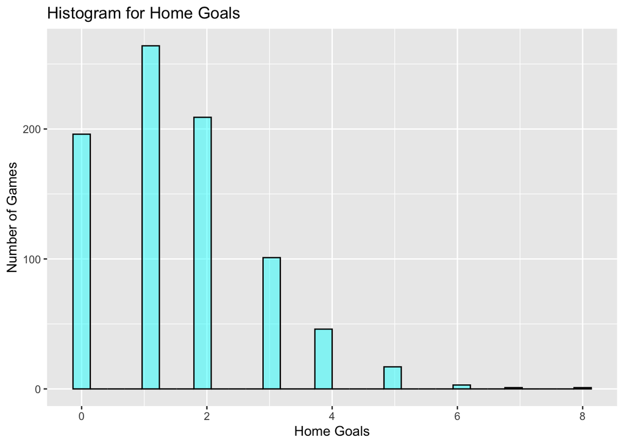

```r
ggplot(data=data_league, aes(x=FTHG), binwidth=1) + geom_histogram(col="black", fill="Cyan", alpha = .5) +labs(title="Histogram for Home Goals", x="Home Goals", y="Number of Games")
```

Task 1b: Histogram for Away Score (Goals)

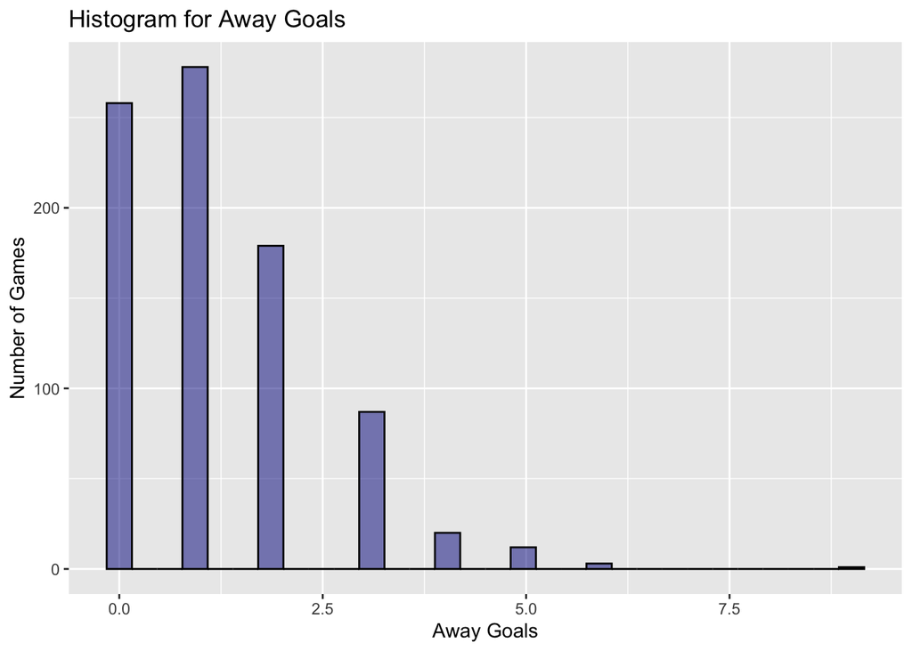

```r
ggplot(data=data_league, aes(x=FTAG), binwidth=1) + geom_histogram(col="black",fill="dark blue", alpha = .5) +
  labs(title="Histogram for Away Goals", x="Away Goals", y="Number of Games")
```

Task 1c: Histogram for Home - Away Score (Goals)

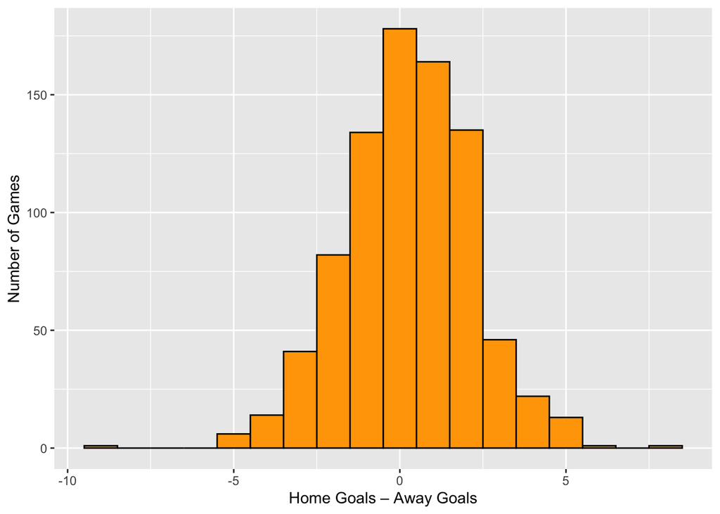

```r
ggplot(data_league) + geom_histogram(aes(x = FTHG-FTAG), binwidth=1, col="black", fill="orange") + xlab("Home Goals – Away Goals") + ylab("Number of Games") + theme(plot.caption=element_text(hjust = 0.5))
```

Part 2: This is the part 2 of the Task 1.

Density curves added to Home Goals and Away Goals Histograms in order to see if they show Poisson distribution characteristics.

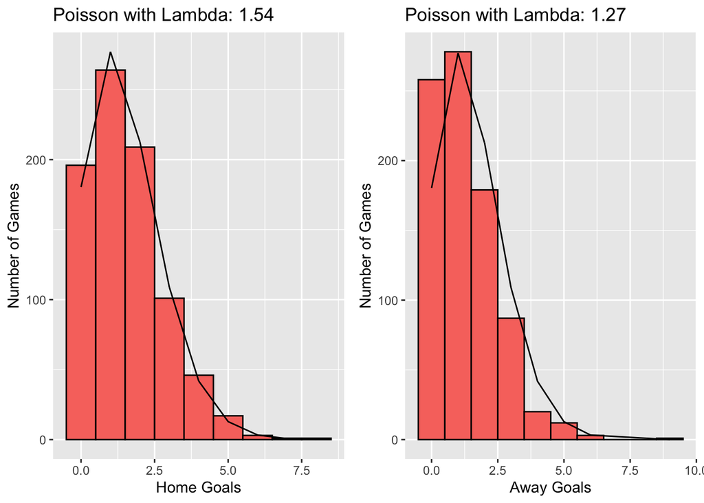

```r
#sample mean calculations and lenght

lambda_hg= mean(data_league$FTHG,trim=0,na.rm=T)
lambda_ag= mean(data_league$FTAG,trim=0,na.rm=T)
n = length(data_league$FTHG)


# poisson density - home

p1=ggplot(data_league,aes(FTHG)) + geom_histogram(aes(fill="Home Goals"),binwidth = 1,col="black",show.legend = FALSE)+
  geom_line(aes(y=dpois(x=FTHG,lambda = lambda_hg)*n)) +
  labs(x="Home Goals",y="Number of Games",title=paste0("Poisson with Lambda: ",round(lambda_hg,2)))

# poisson density - away

p2=ggplot(data_league,aes(FTAG)) + geom_histogram(aes(fill="Away Goals"),binwidth = 1,col="black",show.legend = FALSE)+
  geom_line(aes(y=dpois(x=FTAG,lambda = lambda_hg)*n)) +
  labs(x="Away Goals",y="Number of Games",title=paste0("Poisson with Lambda: ",round(lambda_ag,2)))

# combine home and away plots
grid.arrange(p1,p2,ncol=2)
```

As it can be seen from the density curve added histograms, they show the poisson distribution characteristics.

Task 2

The aim of this task is to understand if bookmakers are good enough in setting their odds for “draw” bets. For this task I choose (B365H, B365D, B365A) , (BWH, BWD, BWA) , (IWH, IWD, IWA) and (PSH, PSD, PSA) as Bookmakers.

Task 2.1 Let’s calculate the P(Home Win), P(Draw) and P(Away Win) for selected bet options:

```r
data_league$prob_B365H <- 1/(data_league$B365H)
data_league$prob_B365D <- 1/(data_league$B365D)
data_league$prob_B365A <- 1/(data_league$B365A)

data_league$prob_BWH <- 1/(data_league$BWH)
data_league$prob_BWD <- 1/(data_league$BWD)
data_league$prob_BWA <- 1/(data_league$BWA)

data_league$prob_IWH <- 1/(data_league$IWH)
data_league$prob_IWD <- 1/(data_league$IWD)
data_league$prob_IWA <- 1/(data_league$IWA)

data_league$prob_PSH <- 1/(data_league$PSH)
data_league$prob_PSA <- 1/(data_league$PSA)
data_league$prob_PSD <- 1/(data_league$PSD)
```

```r
data_league %>%
  colnames()
```

```
##  [1] "Date"       "HomeTeam"   "AwayTeam"   "FTHG"       "FTAG"
##  [6] "FTR"        "HTHG"       "HTAG"       "HTR"        "Referee"
## [11] "HS"         "AS"         "HST"        "AST"        "HF"
## [16] "AF"         "HC"         "AC"         "HY"         "AY"
## [21] "HR"         "AR"         "B365H"      "B365D"      "B365A"
## [26] "BWH"        "BWD"        "BWA"        "IWH"        "IWD"
## [31] "IWA"        "PSH"        "PSD"        "PSA"        "WHH"
## [36] "WHD"        "WHA"        "VCH"        "VCD"        "VCA"
## [41] "Bb1X2"      "BbMxH"      "BbAvH"      "BbMxD"      "BbAvD"
## [46] "BbMxA"      "BbAvA"      "BbOU"       "BbMx>2.5"   "BbAv>2.5"
## [51] "BbMx<2.5"   "BbAv<2.5"   "BbAH"       "BbAHh"      "BbMxAHH"
## [56] "Time"       "MaxH"       "MaxD"       "MaxA"       "AvgH"
## [61] "AvgD"       "AvgA"       "B365>2.5"   "B365<2.5"   "P>2.5"
## [66] "P<2.5"      "Max>2.5"    "Max<2.5"    "Avg>2.5"    "Avg<2.5"
## [71] "prob_B365H" "prob_B365D" "prob_B365A" "prob_BWH"   "prob_BWD"
## [76] "prob_BWA"   "prob_IWH"   "prob_IWD"   "prob_IWA"   "prob_PSH"
## [81] "prob_PSA"   "prob_PSD"
```

Task 2.2 Normalization of the previous odds for each bookmakers:

```r
#Normalized B365:
data_league$N_prob_B365H <- data_league$prob_B365H/(data_league$prob_B365H + data_league$prob_B365D + data_league$prob_B365A)
data_league$N_prob_B365D <- data_league$prob_B365D/(data_league$prob_B365H + data_league$prob_B365D + data_league$prob_B365A)
data_league$N_prob_B365A <- data_league$prob_B365A/(data_league$prob_B365H + data_league$prob_B365D + data_league$prob_B365A)

#Normalized BW:
data_league$N_prob_BWH <- data_league$prob_BWH/(data_league$prob_BWH + data_league$prob_BWD + data_league$prob_BWA)
data_league$N_prob_BWD <- data_league$prob_BWD/(data_league$prob_BWH + data_league$prob_BWD + data_league$prob_BWA)
data_league$N_prob_BWA <- data_league$prob_BWA/(data_league$prob_BWH + data_league$prob_BWD + data_league$prob_BWA)

#Normalized IW:
data_league$N_prob_IWH <- data_league$prob_IWH/(data_league$prob_IWH + data_league$prob_IWD + data_league$prob_IWA)
data_league$N_prob_IWD <- data_league$prob_IWD/(data_league$prob_IWH + data_league$prob_IWD + data_league$prob_IWA)
data_league$N_prob_IWA <- data_league$prob_IWA/(data_league$prob_IWH + data_league$prob_IWD + data_league$prob_IWA)

#Normalized PS:
data_league$N_prob_PSH <- data_league$prob_PSH/(data_league$prob_PSH + data_league$prob_PSA + data_league$prob_PSD)
data_league$N_prob_PSA <- data_league$prob_PSA/(data_league$prob_PSH + data_league$prob_PSA + data_league$prob_PSD)
data_league$N_prob_PSD <- data_league$prob_PSD/(data_league$prob_PSH + data_league$prob_PSA + data_league$prob_PSD)
```

```r
data_league %>%
  colnames()
```

```
##  [1] "Date"         "HomeTeam"     "AwayTeam"     "FTHG"         "FTAG"
##  [6] "FTR"          "HTHG"         "HTAG"         "HTR"          "Referee"
## [11] "HS"           "AS"           "HST"          "AST"          "HF"
## [16] "AF"           "HC"           "AC"           "HY"           "AY"
## [21] "HR"           "AR"           "B365H"        "B365D"        "B365A"
## [26] "BWH"          "BWD"          "BWA"          "IWH"          "IWD"
## [31] "IWA"          "PSH"          "PSD"          "PSA"          "WHH"
## [36] "WHD"          "WHA"          "VCH"          "VCD"          "VCA"
## [41] "Bb1X2"        "BbMxH"        "BbAvH"        "BbMxD"        "BbAvD"
## [46] "BbMxA"        "BbAvA"        "BbOU"         "BbMx>2.5"     "BbAv>2.5"
## [51] "BbMx<2.5"     "BbAv<2.5"     "BbAH"         "BbAHh"        "BbMxAHH"
## [56] "Time"         "MaxH"         "MaxD"         "MaxA"         "AvgH"
## [61] "AvgD"         "AvgA"         "B365>2.5"     "B365<2.5"     "P>2.5"
## [66] "P<2.5"        "Max>2.5"      "Max<2.5"      "Avg>2.5"      "Avg<2.5"
## [71] "prob_B365H"   "prob_B365D"   "prob_B365A"   "prob_BWH"     "prob_BWD"
## [76] "prob_BWA"     "prob_IWH"     "prob_IWD"     "prob_IWA"     "prob_PSH"
## [81] "prob_PSA"     "prob_PSD"     "N_prob_B365H" "N_prob_B365D" "N_prob_B365A"
## [86] "N_prob_BWH"   "N_prob_BWD"   "N_prob_BWA"   "N_prob_IWH"   "N_prob_IWD"
## [91] "N_prob_IWA"   "N_prob_PSH"   "N_prob_PSA"   "N_prob_PSD"
```

Task 2.3: Discretization and Plotting In this part I created 20 bins.

For BET 365 (B365) :

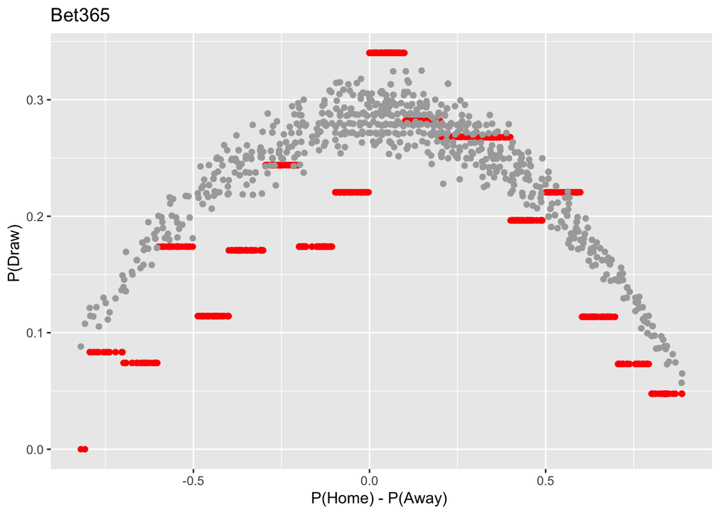

```r
#FTR
data_league = data_league %>%
  mutate(FTR_tie = ifelse(FTR == 'D', 1, 0)) %>%
  mutate(bins = case_when( N_prob_B365H - N_prob_B365A < -0.9  ~ "1",
                           N_prob_B365H - N_prob_B365A < -0.8  ~ "2",
                           N_prob_B365H - N_prob_B365A < -0.7  ~ "3",
                           N_prob_B365H - N_prob_B365A < -0.6  ~ "4",
                           N_prob_B365H - N_prob_B365A < -0.5  ~ "5",
                           N_prob_B365H - N_prob_B365A < -0.4  ~ "6",
                           N_prob_B365H - N_prob_B365A < -0.3  ~ "7",
                           N_prob_B365H - N_prob_B365A < -0.2  ~ "8",
                           N_prob_B365H - N_prob_B365A < -0.1  ~ "9",
                           N_prob_B365H - N_prob_B365A <  0    ~ "10",
                           N_prob_B365H - N_prob_B365A <  0.1  ~ "11",
                           N_prob_B365H - N_prob_B365A <  0.2  ~ "12",
                           N_prob_B365H - N_prob_B365A <  0.3  ~ "13",
                           N_prob_B365H - N_prob_B365A <  0.4  ~ "14",
                           N_prob_B365H - N_prob_B365A <  0.5  ~ "15",
                           N_prob_B365H - N_prob_B365A <  0.6  ~ "16",
                           N_prob_B365H - N_prob_B365A <  0.7  ~ "17",
                           N_prob_B365H - N_prob_B365A <  0.8  ~ "18",
                           N_prob_B365H - N_prob_B365A <  0.9  ~ "19",
                           TRUE ~ "20")) %>%
  group_by(bins) %>%
  mutate(drawB365 = mean(FTR_tie))

p3 <- ggplot() + geom_point(aes(x = N_prob_B365H - N_prob_B365A, y = drawB365), data = data_league, color = "red") +geom_point(aes(x = N_prob_B365H - N_prob_B365A, y = N_prob_B365D), data = data_league, color = "darkgray") +
  labs(title = 'Bet365',
       x = 'P(Home) - P(Away) ',
       y = 'P(Draw) ')
p3
```

For BW:

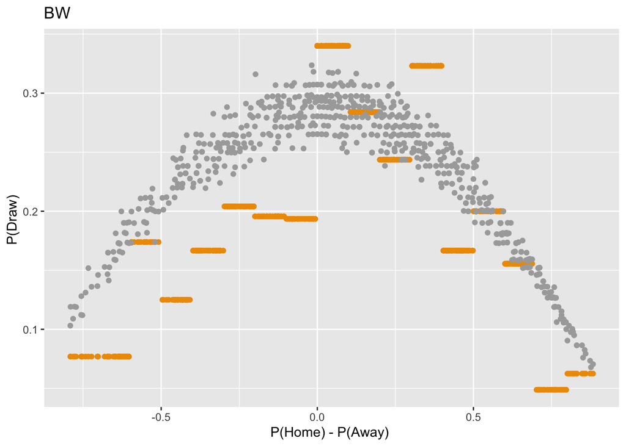

```r
#BW
data_league = data_league %>%
  mutate(FTR_tie = ifelse(FTR == 'D', 1, 0)) %>%
  mutate(bins = case_when( N_prob_BWH - N_prob_BWA < -0.9  ~ "1",
                           N_prob_BWH - N_prob_BWA < -0.8  ~ "2",
                           N_prob_BWH - N_prob_BWA < -0.7  ~ "3",
                           N_prob_BWH - N_prob_BWA < -0.6  ~ "4",
                           N_prob_BWH - N_prob_BWA < -0.5  ~ "5",
                           N_prob_BWH - N_prob_BWA < -0.4  ~ "6",
                           N_prob_BWH - N_prob_BWA < -0.3  ~ "7",
                           N_prob_BWH - N_prob_BWA < -0.2  ~ "8",
                           N_prob_BWH - N_prob_BWA < -0.1  ~ "9",
                           N_prob_BWH - N_prob_BWA <  0    ~ "10",
                           N_prob_BWH - N_prob_BWA <  0.1  ~ "11",
                           N_prob_BWH - N_prob_BWA <  0.2  ~ "12",
                           N_prob_BWH - N_prob_BWA <  0.3  ~ "13",
                           N_prob_BWH - N_prob_BWA <  0.4  ~ "14",
                           N_prob_BWH - N_prob_BWA <  0.5  ~ "15",
                           N_prob_BWH - N_prob_BWA <  0.6  ~ "16",
                           N_prob_BWH - N_prob_BWA <  0.7  ~ "17",
                           N_prob_BWH - N_prob_BWA <  0.8  ~ "18",
                           N_prob_BWH - N_prob_BWA <  0.9  ~ "19",
                           TRUE ~ "20")) %>%
  group_by(bins) %>%
  mutate(drawBW = mean(FTR_tie))

p4 <- ggplot() + geom_point(aes(x = N_prob_BWH - N_prob_BWA, y = drawBW), data = data_league, color = "orange2") +geom_point(aes(x = N_prob_BWH - N_prob_BWA, y = N_prob_BWD), data = data_league, color = "darkgray") +
  labs(title = 'BW',
       x = 'P(Home) - P(Away) ',
       y = 'P(Draw) ')

p4
```

For IW:

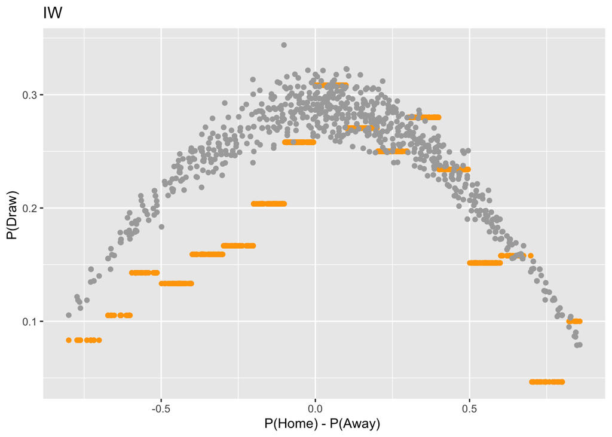

```r
#For IW:
data_league = data_league %>%
  mutate(FTR_tie = ifelse(FTR == 'D', 1, 0)) %>%
  mutate(bins = case_when( N_prob_IWH - N_prob_IWA < -0.9  ~ "1",
                           N_prob_IWH - N_prob_IWA < -0.8  ~ "2",
                           N_prob_IWH - N_prob_IWA < -0.7  ~ "3",
                           N_prob_IWH - N_prob_IWA < -0.6  ~ "4",
                           N_prob_IWH - N_prob_IWA < -0.5  ~ "5",
                           N_prob_IWH - N_prob_IWA < -0.4  ~ "6",
                           N_prob_IWH - N_prob_IWA < -0.3  ~ "7",
                           N_prob_IWH - N_prob_IWA < -0.2  ~ "8",
                           N_prob_IWH - N_prob_IWA < -0.1  ~ "9",
                           N_prob_IWH - N_prob_IWA <  0    ~ "10",
                           N_prob_IWH - N_prob_IWA <  0.1  ~ "11",
                           N_prob_IWH - N_prob_IWA <  0.2  ~ "12",
                           N_prob_IWH - N_prob_IWA <  0.3  ~ "13",
                           N_prob_IWH - N_prob_IWA <  0.4  ~ "14",
                           N_prob_IWH - N_prob_IWA <  0.5  ~ "15",
                           N_prob_IWH - N_prob_IWA <  0.6  ~ "16",
                           N_prob_IWH - N_prob_IWA <  0.7  ~ "17",
                           N_prob_IWH - N_prob_IWA <  0.8  ~ "18",
                           N_prob_IWH - N_prob_IWA <  0.9  ~ "19",
                           TRUE ~ "20")) %>%
  group_by(bins) %>%
  mutate(drawIW = mean(FTR_tie))

p5 <- ggplot() + geom_point(aes(x = N_prob_IWH - N_prob_IWA, y = drawIW), data = data_league, color = "orange") +geom_point(aes(x = N_prob_IWH - N_prob_IWA, y = N_prob_IWD), data = data_league, color = "darkgray") +
  labs(title = 'IW',
       x = 'P(Home) - P(Away) ',
       y = 'P(Draw) ')
p5
```

For PS:

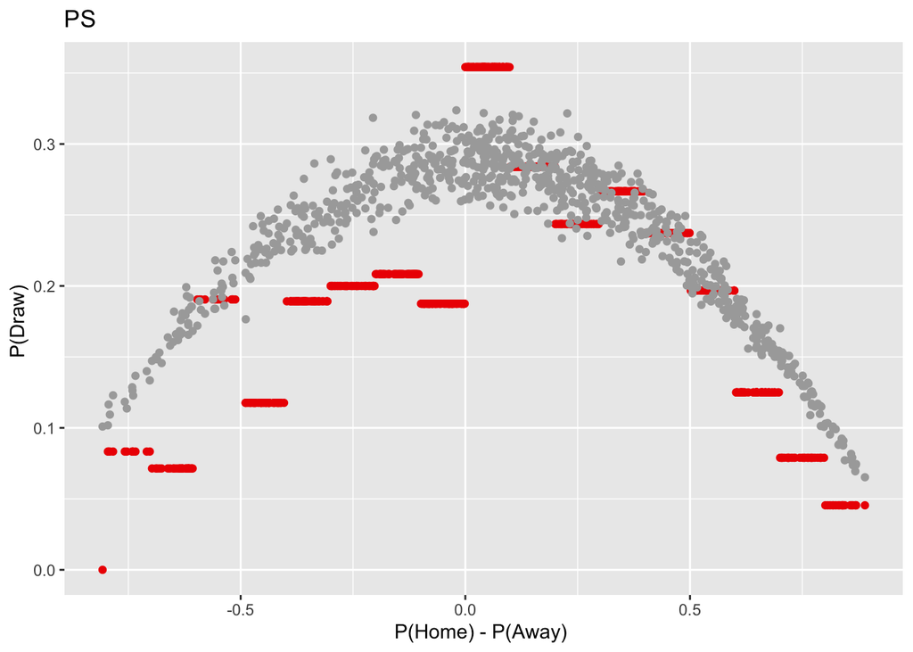

```r
#For PS:
data_league = data_league %>%
  mutate(FTR_tie = ifelse(FTR == 'D', 1, 0)) %>%
  mutate(bins = case_when( N_prob_PSH - N_prob_PSA < -0.9  ~ "1",
                           N_prob_PSH - N_prob_PSA < -0.8  ~ "2",
                           N_prob_PSH - N_prob_PSA < -0.7  ~ "3",
                           N_prob_PSH - N_prob_PSA < -0.6  ~ "4",
                           N_prob_PSH - N_prob_PSA < -0.5  ~ "5",
                           N_prob_PSH - N_prob_PSA < -0.4  ~ "6",
                           N_prob_PSH - N_prob_PSA < -0.3  ~ "7",
                           N_prob_PSH - N_prob_PSA < -0.2  ~ "8",
                           N_prob_PSH - N_prob_PSA < -0.1  ~ "9",
                           N_prob_PSH - N_prob_PSA <  0    ~ "10",
                           N_prob_PSH - N_prob_PSA <  0.1  ~ "11",
                           N_prob_PSH - N_prob_PSA <  0.2  ~ "12",
                           N_prob_PSH - N_prob_PSA <  0.3  ~ "13",
                           N_prob_PSH - N_prob_PSA <  0.4  ~ "14",
                           N_prob_PSH - N_prob_PSA <  0.5  ~ "15",
                           N_prob_PSH - N_prob_PSA <  0.6  ~ "16",
                           N_prob_PSH - N_prob_PSA <  0.7  ~ "17",
                           N_prob_PSH - N_prob_PSA <  0.8  ~ "18",
                           N_prob_PSH - N_prob_PSA <  0.9  ~ "19",
                           TRUE ~ "20")) %>%
  group_by(bins) %>%
  mutate(drawPS = mean(FTR_tie))

p6 <- ggplot() + geom_point(aes(x = N_prob_PSH - N_prob_PSA, y = drawPS), data = data_league, color = "red2") +geom_point(aes(x = N_prob_PSH - N_prob_PSA, y = N_prob_PSD), data = data_league, color = "darkgray") +
  labs(title = 'PS',
       x = 'P(Home) - P(Away) ',
       y = 'P(Draw) ')
p6
```

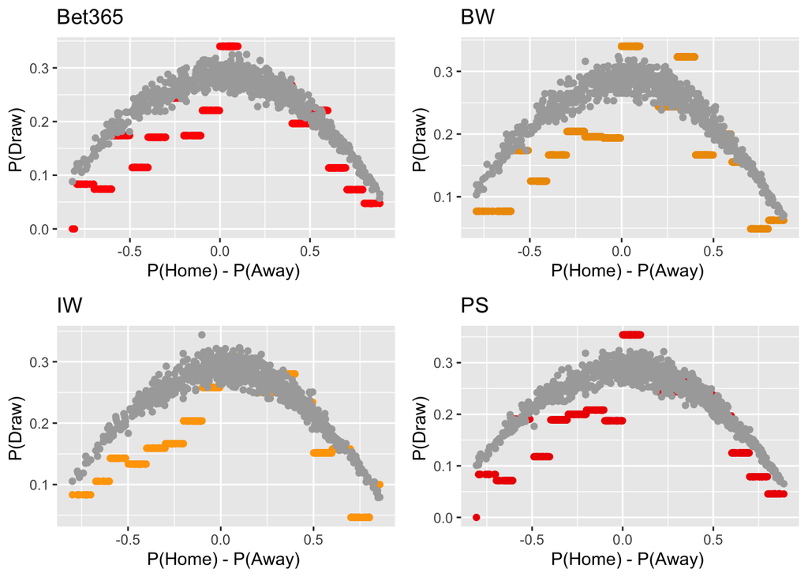

```r
grid.arrange(p3,p4,p5,p6,ncol=2)
```

Results for Task 2: 4 Bookmakers are selected and the results shows us there is a bias between calculated draw probability and actual draw probability.

TASK 3:

There can be some events during the matches that create noise in the outcomes.

Effect of the Red Cards:

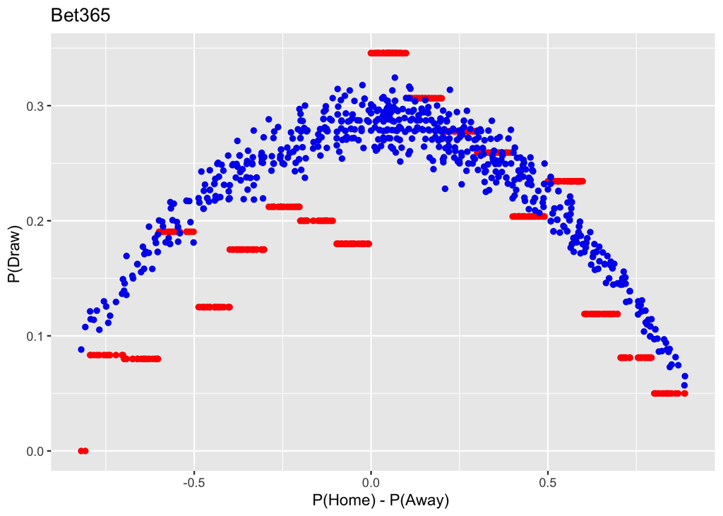

```r
#Red Card for B365:
data_RED = data_league %>%
  filter(HR + AR == 0)

data_RED = data_RED %>%
  mutate(FTR_tie = ifelse(FTR == 'D', 1, 0)) %>%
  mutate(bins = case_when( N_prob_B365H - N_prob_B365A < -0.9  ~ "1",
                           N_prob_B365H - N_prob_B365A < -0.8  ~ "2",
                           N_prob_B365H - N_prob_B365A < -0.7  ~ "3",
                           N_prob_B365H - N_prob_B365A < -0.6  ~ "4",
                           N_prob_B365H - N_prob_B365A < -0.5  ~ "5",
                           N_prob_B365H - N_prob_B365A < -0.4  ~ "6",
                           N_prob_B365H - N_prob_B365A < -0.3  ~ "7",
                           N_prob_B365H - N_prob_B365A < -0.2  ~ "8",
                           N_prob_B365H - N_prob_B365A < -0.1  ~ "9",
                           N_prob_B365H - N_prob_B365A <  0    ~ "10",
                           N_prob_B365H - N_prob_B365A <  0.1  ~ "11",
                           N_prob_B365H - N_prob_B365A <  0.2  ~ "12",
                           N_prob_B365H - N_prob_B365A <  0.3  ~ "13",
                           N_prob_B365H - N_prob_B365A <  0.4  ~ "14",
                           N_prob_B365H - N_prob_B365A <  0.5  ~ "15",
                           N_prob_B365H - N_prob_B365A <  0.6  ~ "16",
                           N_prob_B365H - N_prob_B365A <  0.7  ~ "17",
                           N_prob_B365H - N_prob_B365A <  0.8  ~ "18",
                           N_prob_B365H - N_prob_B365A <  0.9  ~ "19",
                           TRUE ~ "20")) %>%
  group_by(bins) %>%
  mutate(drawB365 = mean(FTR_tie))

p7 <- ggplot() + geom_point(aes(x = N_prob_B365H - N_prob_B365A, y = drawB365), data = data_RED, color = "red") +geom_point(aes(x = N_prob_B365H - N_prob_B365A, y = N_prob_B365D), data = data_RED, color = "blue2") +
  labs(title = 'Bet365',
       x = 'P(Home) - P(Away) ',
       y = 'P(Draw) ')
  p7
```

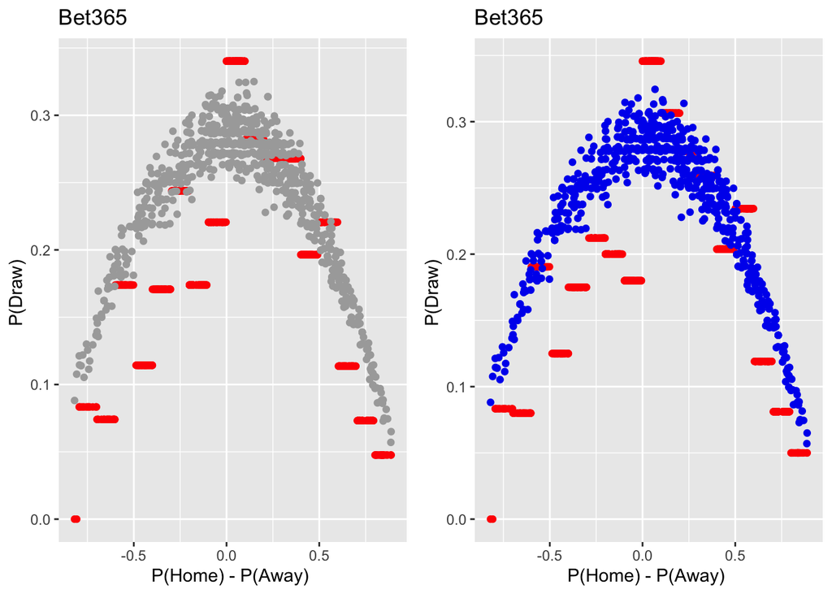

```r
# Comparison between Normal version vs No Red Card version for B365
grid.arrange(p3,p7,ncol=2)
```

For BW:

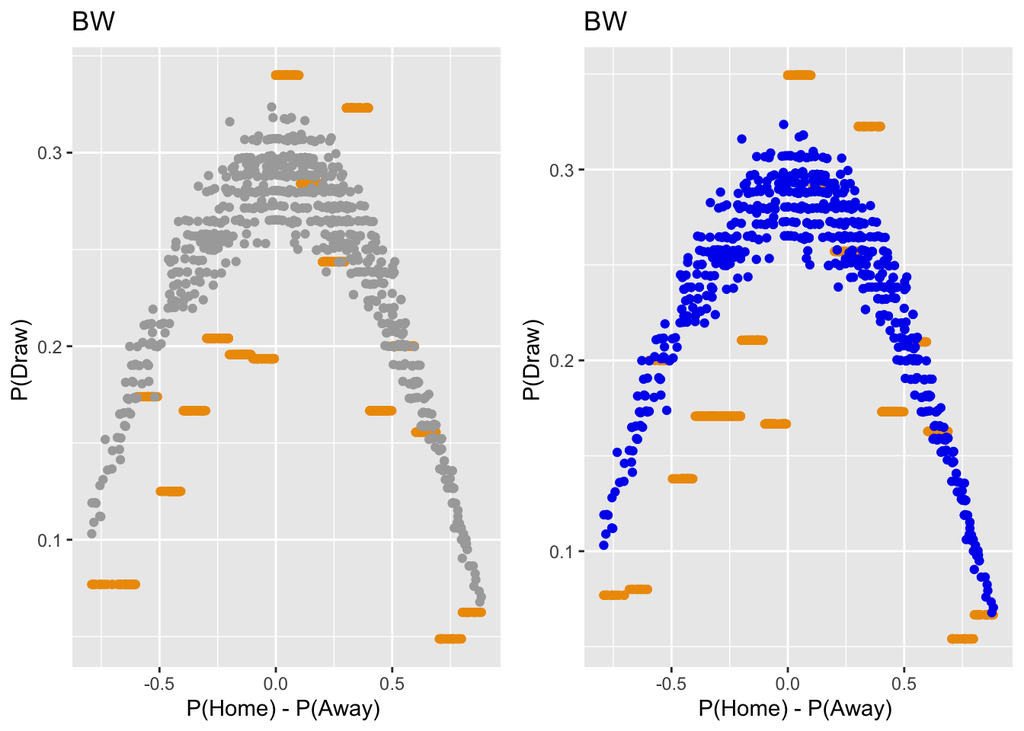

```r
data_RED = data_league %>%
  filter(HR + AR == 0)

data_RED = data_RED %>%
  mutate(FTR_tie = ifelse(FTR == 'D', 1, 0)) %>%
  mutate(bins = case_when( N_prob_BWH - N_prob_BWA < -0.9  ~ "1",
                           N_prob_BWH - N_prob_BWA < -0.8  ~ "2",
                           N_prob_BWH - N_prob_BWA < -0.7  ~ "3",
                           N_prob_BWH - N_prob_BWA < -0.6  ~ "4",
                           N_prob_BWH - N_prob_BWA < -0.5  ~ "5",
                           N_prob_BWH - N_prob_BWA < -0.4  ~ "6",
                           N_prob_BWH - N_prob_BWA < -0.3  ~ "7",
                           N_prob_BWH - N_prob_BWA < -0.2  ~ "8",
                           N_prob_BWH - N_prob_BWA < -0.1  ~ "9",
                           N_prob_BWH - N_prob_BWA <  0    ~ "10",
                           N_prob_BWH - N_prob_BWA <  0.1  ~ "11",
                           N_prob_BWH - N_prob_BWA <  0.2  ~ "12",
                           N_prob_BWH - N_prob_BWA <  0.3  ~ "13",
                           N_prob_BWH - N_prob_BWA <  0.4  ~ "14",
                           N_prob_BWH - N_prob_BWA <  0.5  ~ "15",
                           N_prob_BWH - N_prob_BWA <  0.6  ~ "16",
                           N_prob_BWH - N_prob_BWA <  0.7  ~ "17",
                           N_prob_BWH - N_prob_BWA <  0.8  ~ "18",
                           N_prob_BWH - N_prob_BWA <  0.9  ~ "19",
                           TRUE ~ "20")) %>%
  group_by(bins) %>%
  mutate(drawBW = mean(FTR_tie))

p8 <- ggplot() + geom_point(aes(x = N_prob_BWH - N_prob_BWA, y = drawBW), data = data_RED, color = "orange2") +geom_point(aes(x = N_prob_BWH - N_prob_BWA, y = N_prob_BWD), data = data_RED, color = "blue2") +
  labs(title = 'BW',
       x = 'P(Home) - P(Away) ',
       y = 'P(Draw) ')

# Comparison between Normal Version vs No Red Card Version For BW
grid.arrange(p4,p8,ncol=2)
```

For IW:

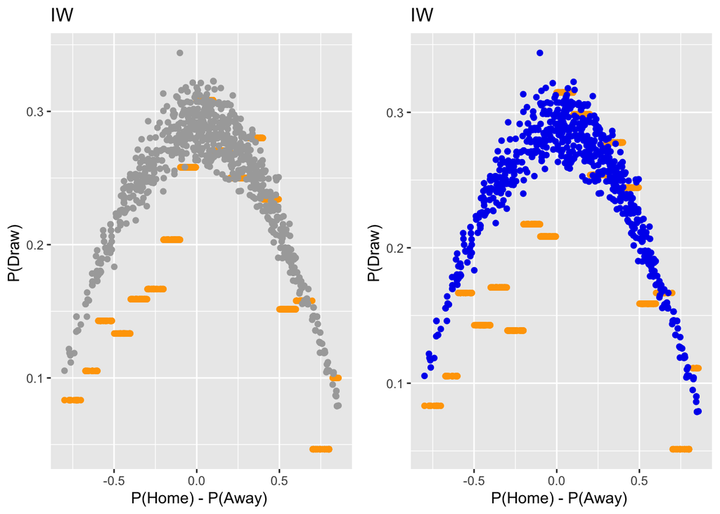

```r
data_RED = data_league %>%
  filter(HR + AR == 0)

data_RED = data_RED %>%
  mutate(FTR_tie = ifelse(FTR == 'D', 1, 0)) %>%
  mutate(bins = case_when( N_prob_IWH - N_prob_IWA < -0.9  ~ "1",
                           N_prob_IWH - N_prob_IWA < -0.8  ~ "2",
                           N_prob_IWH - N_prob_IWA < -0.7  ~ "3",
                           N_prob_IWH - N_prob_IWA < -0.6  ~ "4",
                           N_prob_IWH - N_prob_IWA < -0.5  ~ "5",
                           N_prob_IWH - N_prob_IWA < -0.4  ~ "6",
                           N_prob_IWH - N_prob_IWA < -0.3  ~ "7",
                           N_prob_IWH - N_prob_IWA < -0.2  ~ "8",
                           N_prob_IWH - N_prob_IWA < -0.1  ~ "9",
                           N_prob_IWH - N_prob_IWA <  0    ~ "10",
                           N_prob_IWH - N_prob_IWA <  0.1  ~ "11",
                           N_prob_IWH - N_prob_IWA <  0.2  ~ "12",
                           N_prob_IWH - N_prob_IWA <  0.3  ~ "13",
                           N_prob_IWH - N_prob_IWA <  0.4  ~ "14",
                           N_prob_IWH - N_prob_IWA <  0.5  ~ "15",
                           N_prob_IWH - N_prob_IWA <  0.6  ~ "16",
                           N_prob_IWH - N_prob_IWA <  0.7  ~ "17",
                           N_prob_IWH - N_prob_IWA <  0.8  ~ "18",
                           N_prob_IWH - N_prob_IWA <  0.9  ~ "19",
                           TRUE ~ "20")) %>%
  group_by(bins) %>%
  mutate(drawIW = mean(FTR_tie))

p9 <- ggplot() + geom_point(aes(x = N_prob_IWH - N_prob_IWA, y = drawIW), data = data_RED, color = "orange") +geom_point(aes(x = N_prob_IWH - N_prob_IWA, y = N_prob_IWD), data = data_RED, color = "blue2") +
  labs(title = 'IW',
       x = 'P(Home) - P(Away) ',
       y = 'P(Draw) ')

# Comparison between Normal Version vs No Red Card Version For IW
grid.arrange(p5,p9,ncol=2)
```

For PS:

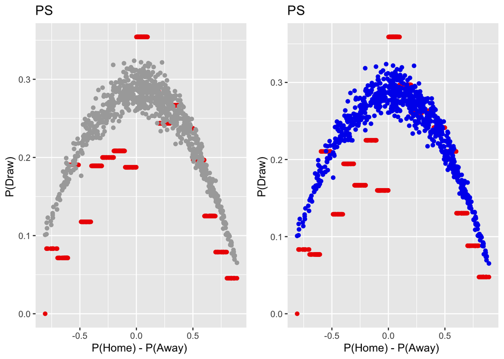

```r
data_RED = data_league %>%
  filter(HR + AR == 0)

data_RED = data_RED %>%
  mutate(FTR_tie = ifelse(FTR == 'D', 1, 0)) %>%
  mutate(bins = case_when( N_prob_PSH - N_prob_PSA < -0.9  ~ "1",
                           N_prob_PSH - N_prob_PSA < -0.8  ~ "2",
                           N_prob_PSH - N_prob_PSA < -0.7  ~ "3",
                           N_prob_PSH - N_prob_PSA < -0.6  ~ "4",
                           N_prob_PSH - N_prob_PSA < -0.5  ~ "5",
                           N_prob_PSH - N_prob_PSA < -0.4  ~ "6",
                           N_prob_PSH - N_prob_PSA < -0.3  ~ "7",
                           N_prob_PSH - N_prob_PSA < -0.2  ~ "8",
                           N_prob_PSH - N_prob_PSA < -0.1  ~ "9",
                           N_prob_PSH - N_prob_PSA <  0    ~ "10",
                           N_prob_PSH - N_prob_PSA <  0.1  ~ "11",
                           N_prob_PSH - N_prob_PSA <  0.2  ~ "12",
                           N_prob_PSH - N_prob_PSA <  0.3  ~ "13",
                           N_prob_PSH - N_prob_PSA <  0.4  ~ "14",
                           N_prob_PSH - N_prob_PSA <  0.5  ~ "15",
                           N_prob_PSH - N_prob_PSA <  0.6  ~ "16",
                           N_prob_PSH - N_prob_PSA <  0.7  ~ "17",
                           N_prob_PSH - N_prob_PSA <  0.8  ~ "18",
                           N_prob_PSH - N_prob_PSA <  0.9  ~ "19",
                           TRUE ~ "20")) %>%
  group_by(bins) %>%
  mutate(drawPS = mean(FTR_tie))

p10 <- ggplot() + geom_point(aes(x = N_prob_PSH - N_prob_PSA, y = drawPS), data = data_RED, color = "red2") +geom_point(aes(x = N_prob_PSH - N_prob_PSA, y = N_prob_PSD), data = data_RED, color = "blue2") +
  labs(title = 'PS',
       x = 'P(Home) - P(Away) ',
       y = 'P(Draw) ')

# Comparison between Normal Version vs No Red Card Version For PS
grid.arrange(p6,p10,ncol=2)
```

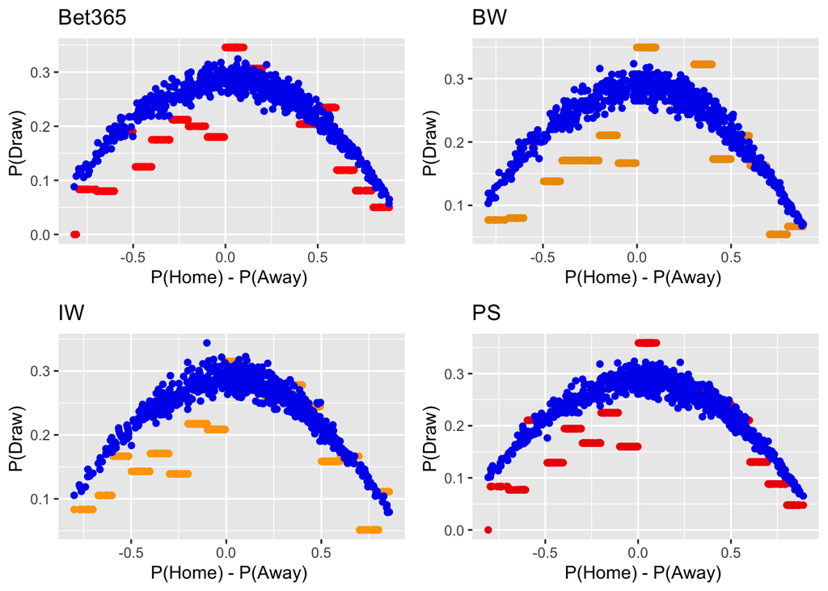

```r
# See all the plots at once with no red cards scenario.
grid.arrange(p7,p8,p9,p10,ncol=2)
```